# Logins Data Modeling

Sathya Anand

#### Load data files from model exploration notebook

Length of input time series

```
## [1] 9786
```

Length after truncating one season

```
## [1] 9113
```

Exogenous variables matrix dimensions and sample of rows

```
## [1] 9113    3
```

```
##           ysp    ysp_m1    ysp_p1
## 673 3.0618622 2.7156951 2.5248762
## 674 2.7156951 1.1726039 3.0618622
## 675 1.1726039 2.0916501 2.7156951
## 676 2.0916501 0.6123724 1.1726039
## 677 0.6123724 2.0916501 2.0916501
## 678 2.0916501 3.0618622 0.6123724
```

#### Let’s figure out the best ARIMA model

Using seasonal components in ARIMA with large period lengths causes memory issues. Here, we stick to non-seasonal ARIMA with seasonal lags thrown in as covariates. This is not entirely rigorous but should work well in practical settings.

```r
model = auto.arima(ytrunc, d=1,
                   max.p=10, max.q=10, max.d=2,
                   xreg=exog,
                   stationary=TRUE,
                   approximation=FALSE,
                   allowmean=FALSE)
summary(model)
```

```
## Series: ytrunc
## ARIMA(3,0,1) with zero mean
##
## Coefficients:
##          ar1      ar2      ar3      ma1     ysp  ysp_m1  ysp_p1
##       1.2183  -0.1553  -0.0722  -0.8290  0.2738  0.2222  0.2312
## s.e.  0.0224   0.0181   0.0162   0.0198  0.0108  0.0105  0.0106
##
## sigma^2 estimated as 0.4145:  log likelihood=-8918.39
## AIC=17852.77   AICc=17852.79   BIC=17909.71
##
## Training set error measures:
##                      ME      RMSE       MAE       MPE     MAPE     MASE
## Training set 0.04397416 0.6437896 0.5104306 -6.272713 23.49235 0.858527
##                      ACF1
## Training set -0.008323053
```

#### Model diagnostics

Residuals, ACF, and Ljung-Box plots

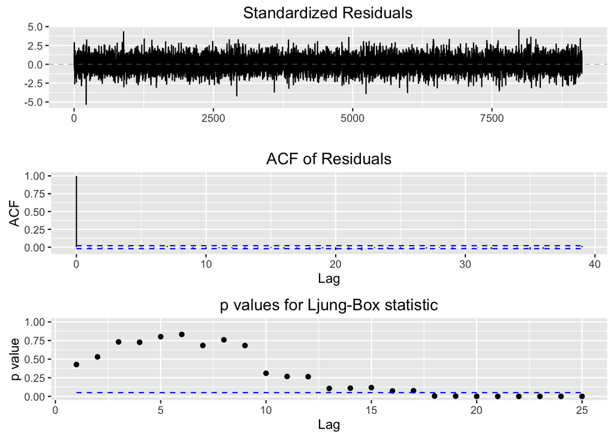

```r
ggtsdiag(model, gof.lag=25)
```

Residuals QQ plot

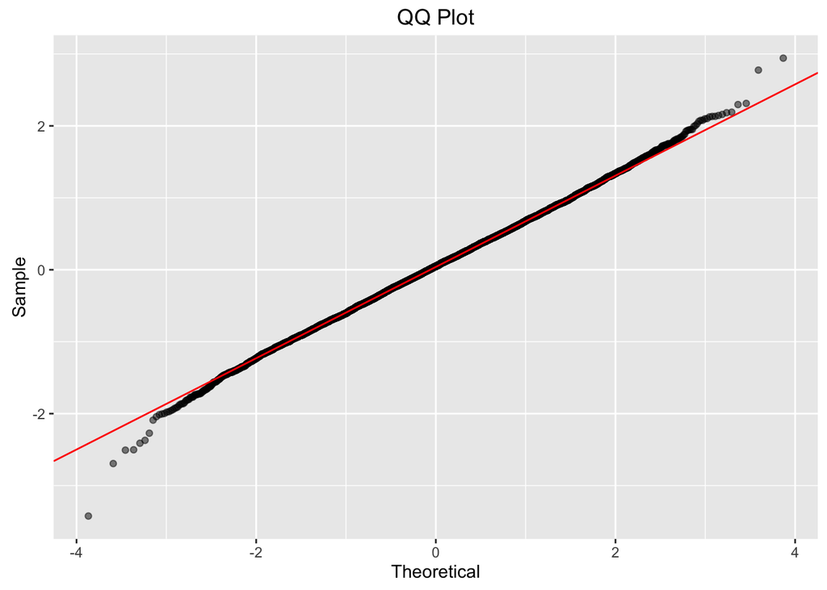

#### Model Predictions

Dimensions and sample of future covariates

```
## [1] 16  3
```

```
##           ysp   ysp_m1   ysp_p1
## 9786 2.091650 2.524876 1.837117
## 9787 1.837117 2.091650 2.893959
## 9788 2.893959 1.837117 2.715695
## 9789 2.715695 2.893959 3.372684
## 9790 3.372684 2.715695 2.318405
## 9791 2.318405 3.372684 3.657185
```

Run predictions

```r
predictions = forecast(model, xreg=new_exog)
print(predictions)
```

```
##      Point Forecast    Lo 80    Hi 80     Lo 95    Hi 95
## 9114       2.249273 1.424223 3.074322 0.9874681 3.511077
## 9115       2.325194 1.439811 3.210577 0.9711176 3.679270
## 9116       2.485869 1.562191 3.409547 1.0732254 3.898513
## 9117       2.810518 1.863005 3.758032 1.3614216 4.259615
## 9118       2.695853 1.728841 3.662865 1.2169364 4.174770
## 9119       2.853331 1.869048 3.837613 1.3480006 4.358661
## 9120       2.976954 1.976637 3.977272 1.4471004 4.506809
## 9121       3.165291 2.149803 4.180778 1.6122368 4.718345
## 9122       3.037733 2.007769 4.067697 1.4625393 4.612927
## 9123       2.932834 1.889000 3.976669 1.3364277 4.529241
## 9124       2.924983 1.867831 3.982134 1.3082094 4.541756
## 9125       3.190217 2.120265 4.260170 1.5538661 4.826569
## 9126       3.394774 2.312505 4.477043 1.7395869 5.049961
## 9127       3.356151 2.262025 4.450277 1.6828300 5.029472
## 9128       3.182095 2.076547 4.287642 1.4913056 4.872884
## 9129       3.112125 1.995569 4.228681 1.4045003 4.819749
```

Plot predictions in transformed space (Only last full season shown here for clarity)

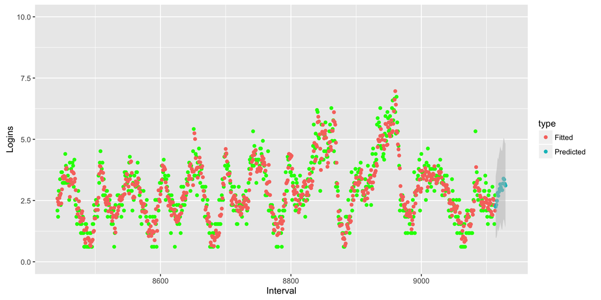

Reverse transformation and plot in original space (Only last full season shown here for clarity)

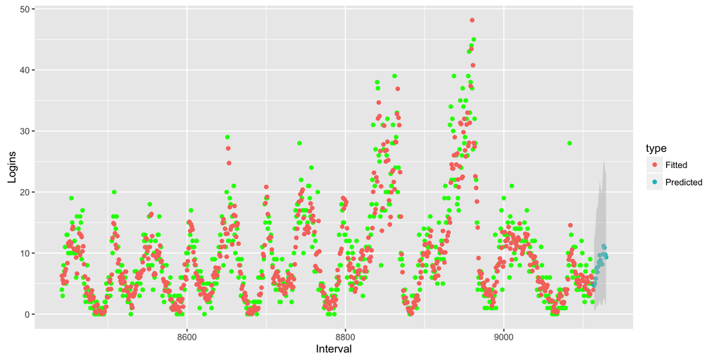

#### Estimating predictive accuracy of model

While the RMSE from the model gives an indication of in-sample residual standard deviations, a truly predictive RMSE can be found by doing rolling estimation and forecasts over the window of interest.

In this case, we are interested in forecasting 4 periods ahead. If we have, as an example, 100 observed periods, we can train the model on 96 periods and calculate a prediction error on the last 4 periods. We can roll the training window back recursively to get better estimates on the error.

Note: this may take a while to generate.

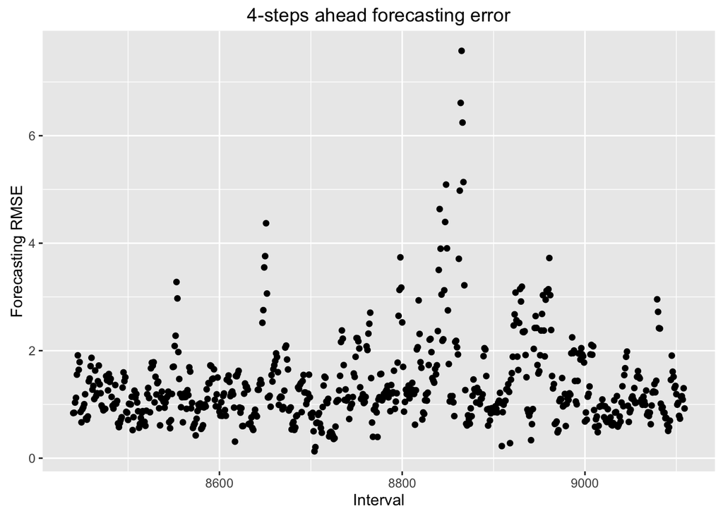

The plot above indicates that our model does a decent job keeping prediction errors within a constrained band for the most part. However, there are clusters of intervals where the model performs poorly.

Given more time, one can look into what cause these RMSEs spikes, and if the model can be tweaked to do a better job.